# Assignement: EDA of NEI records of PM2.5

## EDA of NEI records of PM2.5 for 1999, 2002, 2005, and 2008 (part of Exploratory Data Analysis by Johns Hopkins University)

This assignement focused only on plots as part of EDA. We did not checked for erroneous/missing data. Source code available on [GitHub](https://github.com/bmaingret/NEI_199-2008_EDA)

## Quick look at the data

```r
NEI <- as_tibble(NEI)
SCC <- as_tibble(SCC)
str(NEI)
```

```
Classes ‘tbl_df’, ‘tbl’ and 'data.frame':   6497651 obs. of  6 variables:
 $ fips     : chr  "09001" "09001" "09001" "09001" ...
 $ SCC      : chr  "10100401" "10100404" "10100501" "10200401" ...
 $ Pollutant: chr  "PM25-PRI" "PM25-PRI" "PM25-PRI" "PM25-PRI" ...
 $ Emissions: num  15.714 234.178 0.128 2.036 0.388 ...
 $ type     : chr  "POINT" "POINT" "POINT" "POINT" ...
 $ year     : int  1999 1999 1999 1999 1999 1999 1999 1999 1999 1999 ...
```

```r
str(SCC)
```

```
Classes ‘tbl_df’, ‘tbl’ and 'data.frame':   11717 obs. of  15 variables:
 $ SCC                : Factor w/ 11717 levels "10100101","10100102",..: 1 2 3 4 5 6 7 8 9 10 ...
 $ Data.Category      : Factor w/ 6 levels "Biogenic","Event",..: 6 6 6 6 6 6 6 6 6 6 ...
 $ Short.Name         : Factor w/ 11238 levels "","2,4-D Salts and Esters Prod /Process Vents, 2,4-D Recovery: Filtration",..: 3283 3284 3293 3291 3290 3294 3295 3296 3292 3289 ...
 $ EI.Sector          : Factor w/ 59 levels "Agriculture - Crops & Livestock Dust",..: 18 18 18 18 18 18 18 18 18 18 ...
 $ Option.Group       : Factor w/ 25 levels "","C/I Kerosene",..: 1 1 1 1 1 1 1 1 1 1 ...
 $ Option.Set         : Factor w/ 18 levels "","A","B","B1A",..: 1 1 1 1 1 1 1 1 1 1 ...
 $ SCC.Level.One      : Factor w/ 17 levels "Brick Kilns",..: 3 3 3 3 3 3 3 3 3 3 ...
 $ SCC.Level.Two      : Factor w/ 146 levels "","Agricultural Chemicals Production",..: 32 32 32 32 32 32 32 32 32 32 ...
 $ SCC.Level.Three    : Factor w/ 1061 levels "","100% Biosolids (e.g., sewage sludge, manure, mixtures of these matls)",..: 88 88 156 156 156 156 156 156 156 156 ...
 $ SCC.Level.Four     : Factor w/ 6084 levels "","(NH4)2 SO4 Acid Bath System and Evaporator",..: 4455 5583 4466 4458 1341 5246 5584 5983 4461 776 ...
 $ Map.To             : num  NA NA NA NA NA NA NA NA NA NA ...
 $ Last.Inventory.Year: int  NA NA NA NA NA NA NA NA NA NA ...
 $ Created_Date       : Factor w/ 57 levels "","1/27/2000 0:00:00",..: 1 1 1 1 1 1 1 1 1 1 ...
 $ Revised_Date       : Factor w/ 44 levels "","1/27/2000 0:00:00",..: 1 1 1 1 1 1 1 1 1 1 ...
 $ Usage.Notes        : Factor w/ 21 levels ""," ","includes bleaching towers, washer hoods, filtrate tanks, vacuum pump exhausts",..: 1 1 1 1 1 1 1 1 1 1 ...
```

The NEI data is the amount of a specific *Pollutant* for a specific source *SCC* for a *year* in a county indicated by its *FIPS* code. The *type* represents the type of the emission sources as described [here](https://www.epa.gov/air-emissions-inventories/national-emissions-inventory-nei).

Let’s factorize the string values for NEI and check a summary of the NEI.

```r
NEI$fips <- parse_factor(NEI$fips)
NEI$SCC <- parse_factor(NEI$SCC, levels = levels(SCC$SCC))
NEI$Pollutant <- parse_factor(NEI$Pollutant)
NEI$type <- parse_factor(NEI$type)
NEI$year <- parse_factor(as.character(NEI$year))
summary(NEI)
```

```
      fips                 SCC             Pollutant         Emissions              type           year
 48201  :   9442   2275050011:  20301   PM25-PRI:6497651   Min.   :     0.0   POINT   : 516031   1999:1108469
 06037  :   9320   2275070000:  16435                      1st Qu.:     0.0   NONPOINT: 473759   2002:1698677
 17031  :   7596   2275020000:  13926                      Median :     0.0   ON-ROAD :3183599   2005:1713850
 06071  :   5710   2275050012:  12924                      Mean   :     3.4   NON-ROAD:2324262   2008:1976655
 42003  :   5104   2265004010:  12881                      3rd Qu.:     0.1
 06029  :   4970   2260004020:  12821                      Max.   :646952.0
 (Other):6455509   (Other)   :6408363
```

Similar summary for SCC.

```r
summary(SCC)
```

```
       SCC         Data.Category                                                           Short.Name                                                 EI.Sector
 10100101:    1   Biogenic:  82                                                                 :   61   Industrial Processes - Storage and Transfer       :1955
 10100102:    1   Event   :  71   Paved Roads /unknown /unknown                                 :   12   Industrial Processes - Chemical Manuf             :1702
 10100201:    1   Nonpoint:2305   Unpaved Roads /unknown /unknown                               :   12   Industrial Processes - NEC                        :1573
 10100202:    1   Nonroad : 572   Misc Manuf / Indus Processes /Other Not Classified            :   10   Solvent - Industrial Surface Coating & Solvent Use: 992
 10100203:    1   Onroad  :1137   Marine Vessels, Military /unknown                             :    8   Mobile - On-Road Gasoline Light Duty Vehicles     : 518
 10100204:    1   Point   :7550   Pulp&Paper&Wood /Fugitive Emissions /Specify in Comments Field:    6   Solvent - Degreasing                              : 390
 (Other) :11711                   (Other)                                                       :11608   (Other)                                           :4587
               Option.Group     Option.Set                              SCC.Level.One                      SCC.Level.Two
                     :11450          :11436   Industrial Processes             :4787   Chemical Manufacturing     :1264
 P and P Product Tran:   44   B      :   84   Mobile Sources                   :1787   Mineral Products           : 867
 Consumer/Commercial :   40   B1B    :   44   Petroleum and Solvent Evaporation:1563   Highway Vehicles - Gasoline: 621
 Commercial          :   30   B2B    :   37   Solvent Utilization              :1061   Organic Chemical Storage   : 605
 Cattle              :   24   A      :   24   MACT Source Categories           : 686   Food and Agriculture       : 528
 Poultry             :   20   B7B    :   19   Storage and Transport            : 489   Highway Vehicles - Diesel  : 516
 (Other)             :  109   (Other):   73   (Other)                          :1344   (Other)                    :7316
                                               SCC.Level.Three                   SCC.Level.Four      Map.To          Last.Inventory.Year             Created_Date
 All Processes                                         :  168   Other Not Classified    :  204   Min.   :2.020e+07   Min.   :1999                          :9988
 Lawn and Garden Equipment                             :  143   Total                   :  197   1st Qu.:3.040e+07   1st Qu.:1999        2/13/2002 0:00:00 : 492
 Construction and Mining Equipment                     :  138   Total: All Solvent Types:  152   Median :3.079e+07   Median :2002        12/10/1999 0:00:00: 363
 Heavy Duty Gasoline Vehicles 2B thru 8B & Buses (HDGV):  112   General                 :  114   Mean   :3.017e+08   Mean   :2002        4/14/2009 0:00:00 : 166
 Light Duty Gasoline Trucks 1 & 2 (M6) = LDGT1 (M5)    :  112   Special Naphthas        :  106   3rd Qu.:4.030e+07   3rd Qu.:2005        10/19/2011 0:00:00:  62
 Light Duty Gasoline Trucks 3 & 4 (M6) = LDGT2 (M5)    :  112   Solvents: NEC           :   98   Max.   :2.805e+09   Max.   :2008        4/15/2010 0:00:00 :  61
 (Other)                                               :10932   (Other)                 :10846   NA's   :11358       NA's   :8972        (Other)           : 585
            Revised_Date
                  :9090
 4/14/2003 0:00:00: 874
 7/25/2008 0:00:00: 838
 7/27/2008 0:00:00: 272
 2/13/2002 0:00:00:  95
 4/15/2010 0:00:00:  61
 (Other)          : 487
                                                                                                                                                             Usage.Notes
                                                                                                                                                                   :11693
                                                                                                                                                                   :    5
 includes bleaching towers, washer hoods, filtrate tanks, vacuum pump exhausts                                                                                     :    1
 includes causticizer vents only or slaker and causticizer vents combined                                                                                          :    1
 includes components within vacuum drum and non-vacuum drum systems including washer hoods, filtrate tank vents, and vacuum pump exhaust (some deckers and screens):    1
 includes gases not in other low volume high concentration (LVHC) vent sources                                                                                     :    1
 (Other)                                                                                                                                                           :   15
```

Some values seems missing. Quick overview.

```r
summary(is.na(SCC))
```

```
    SCC          Data.Category   Short.Name      EI.Sector       Option.Group    Option.Set      SCC.Level.One   SCC.Level.Two   SCC.Level.Three SCC.Level.Four    Map.To
 Mode :logical   Mode :logical   Mode :logical   Mode :logical   Mode :logical   Mode :logical   Mode :logical   Mode :logical   Mode :logical   Mode :logical   Mode :logical
 FALSE:11717     FALSE:11717     FALSE:11717     FALSE:11717     FALSE:11717     FALSE:11717     FALSE:11717     FALSE:11717     FALSE:11717     FALSE:11717     FALSE:359
                                                                                                                                                                 TRUE :11358
 Last.Inventory.Year Created_Date    Revised_Date    Usage.Notes
 Mode :logical       Mode :logical   Mode :logical   Mode :logical
 FALSE:2745          FALSE:11717     FALSE:11717     FALSE:11717
 TRUE :8972
```

## Binding the two dataframes

```r
data <- NEI %>%
  left_join(SCC, by = c("SCC" = "SCC"))
str(data)
```

```
Classes ‘tbl_df’, ‘tbl’ and 'data.frame':   6497651 obs. of  20 variables:
 $ fips               : Factor w/ 3263 levels "09001","09003",..: 1 1 1 1 1 1 1 1 1 1 ...
 $ SCC                : Factor w/ 11717 levels "10100101","10100102",..: 31 32 35 113 121 124 125 186 190 193 ...
 $ Pollutant          : Factor w/ 1 level "PM25-PRI": 1 1 1 1 1 1 1 1 1 1 ...
 $ Emissions          : num  15.714 234.178 0.128 2.036 0.388 ...
 $ type               : Factor w/ 4 levels "POINT","NONPOINT",..: 1 1 1 1 1 1 1 1 1 1 ...
 $ year               : Factor w/ 4 levels "1999","2002",..: 1 1 1 1 1 1 1 1 1 1 ...
 $ Data.Category      : Factor w/ 6 levels "Biogenic","Event",..: 6 6 6 6 6 6 6 6 6 6 ...
 $ Short.Name         : Factor w/ 11238 levels "","2,4-D Salts and Esters Prod /Process Vents, 2,4-D Recovery: Filtration",..: 3339 3340 3300 3424 3391 3410 3408 3268 3247 3246 ...
 $ EI.Sector          : Factor w/ 59 levels "Agriculture - Crops & Livestock Dust",..: 20 20 20 25 25 24 24 15 15 15 ...
 $ Option.Group       : Factor w/ 25 levels "","C/I Kerosene",..: 1 1 1 1 1 1 1 1 1 1 ...
 $ Option.Set         : Factor w/ 18 levels "","A","B","B1A",..: 1 1 1 1 1 1 1 1 1 1 ...
 $ SCC.Level.One      : Factor w/ 17 levels "Brick Kilns",..: 3 3 3 3 3 3 3 3 3 3 ...
 $ SCC.Level.Two      : Factor w/ 146 levels "","Agricultural Chemicals Production",..: 32 32 32 52 52 52 52 22 22 22 ...
 $ SCC.Level.Three    : Factor w/ 1061 levels "","100% Biosolids (e.g., sewage sludge, manure, mixtures of these matls)",..: 886 886 317 886 317 692 692 886 317 317 ...
 $ SCC.Level.Four     : Factor w/ 6084 levels "","(NH4)2 SO4 Acid Bath System and Evaporator",..: 2545 2546 2548 2544 2525 30 3 2544 2548 2525 ...
 $ Map.To             : num  NA NA NA NA NA NA NA NA NA NA ...
 $ Last.Inventory.Year: int  NA NA NA NA NA NA NA NA NA NA ...
 $ Created_Date       : Factor w/ 57 levels "","1/27/2000 0:00:00",..: 1 1 1 1 1 1 1 1 1 1 ...
 $ Revised_Date       : Factor w/ 44 levels "","1/27/2000 0:00:00",..: 1 1 1 1 1 1 1 1 1 1 ...
 $ Usage.Notes        : Factor w/ 21 levels ""," ","includes bleaching towers, washer hoods, filtrate tanks, vacuum pump exhausts",..: 1 1 1 1 1 1 1 1 1 1 ...
```

## Answering assignement’s questions with plots

### 1. Have total emissions from PM2.5 decreased in the United States from 1999 to 2008?

*Using base plotting system*

```r
totals <- data %>% group_by(year) %>%
  summarise(total = sum(Emissions)/10^6)
```

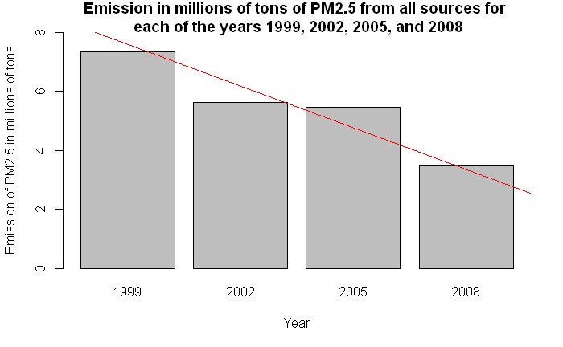

```r
barplot(totals$total,
        names.arg = totals$year,
        main = "Emission in millions of tons of PM2.5 from all sources for \n each of the years 1999, 2002, 2005, and 2008",
        xlab = "Year",
        ylab = "Emission of PM2.5 in millions of tons",
        ylim = c(0,8))
abline(lm( totals$total ~as.numeric(totals$year)), col="red")
```

```r
dev.print(device = png, file = "plot1.png", width = 500, pointsize=10)
```

### 2. Have total emissions from PM2.5 decreased in the Baltimore City, Maryland *(fips == “24510”)* from 1999 to 2008?

*Using base plotting system*

```r
totals_baltimore <- data %>% filter(fips == "24510") %>%
  group_by(year) %>%
  summarise(total = sum(Emissions))
```

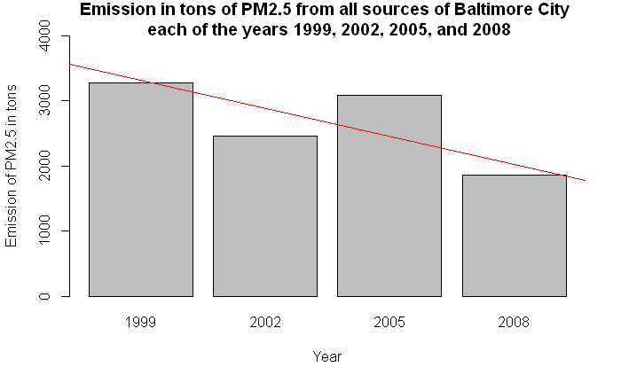

```r
barplot(totals_baltimore$total,
        names.arg = totals_baltimore$year,
        main = "Emission in tons of PM2.5 from all sources of Baltimore City \n each of the years 1999, 2002, 2005, and 2008",
        xlab = "Year",
        ylab = "Emission of PM2.5 in tons",
        ylim = (c(0,4000)))

abline(lm( totals_baltimore$total ~as.numeric(totals_baltimore$year)), col="red")
```

```r
dev.print(device = png, file = "plot2.png", width = 500, pointsize=10)
```

### 3. Of the four types of sources indicated by the *type (point, nonpoint, onroad, nonroad)* variable, which of these four sources have seen decreases in emissions from 1999–2008 for Baltimore City? Which have seen increases in emissions from 1999–2008?

*Using ggplot2 plotting system*

```r
totals_baltimore_type <- data %>% filter(fips == "24510") %>%
  group_by(type, year) %>%
  summarise(total = sum(Emissions)) %>%
  mutate(year=as.numeric(levels(year))[year])
```

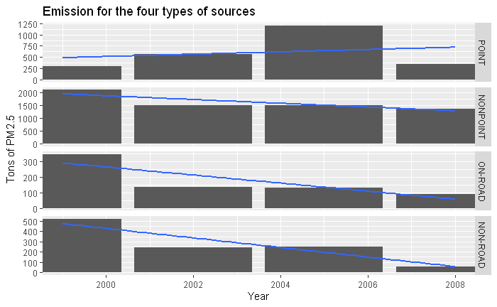

```r
g<-ggplot(totals_baltimore_type) + geom_col(aes(x = year, y = total)) + geom_smooth(method = lm, aes(x = year, y = total), se = FALSE) + facet_grid(rows=vars(type), scales = "free_y")
g <- g + labs(x="Year", y ="Tons of PM2.5", title="Emission for the four types of sources")
g <- g + coord_cartesian(xlim=c(1999,2008))
print(g)
```

### 4. Across the United States, how have emissions from coal combustion-related sources changed from 1999–2008?

```r
totals_coal <- data %>% filter(EI.Sector == "Fuel Comb - Comm/Institutional - Coal") %>%
  group_by(year) %>%
  summarise(total = sum(Emissions)) %>%
  mutate(year=as.numeric(levels(year))[year])
```

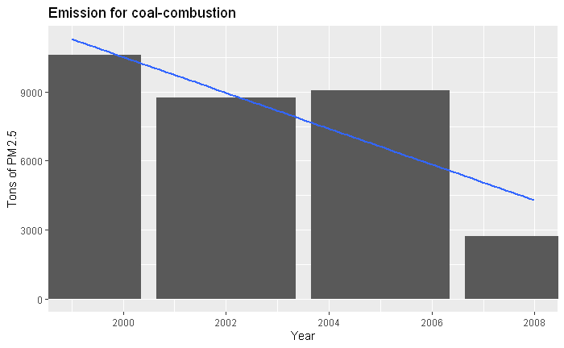

```r
g <- ggplot(totals_coal) + geom_col(aes(x = year, y = total)) + geom_smooth(method = lm, aes(x = as.numeric(year), y = total), se = FALSE)
g <- g + labs(x="Year", y ="Tons of PM2.5", title="Emission for coal-combustion")
g <- g + coord_cartesian(xlim=c(1999,2008))
print(g)
```

### 5. How have emissions from motor vehicle sources changed from 1999–2008 in Baltimore City?

**Hypothesis:** We consider that those emissions are represented by the type *onroad* considering the information for [epa.gov](https://www.epa.gov/air-emissions-inventories/national-emissions-inventory-nei) : “NEI onroad sources include emissions from onroad vehicles that use gasoline, diesel, and other fuels”

```r
totals_vehicle <- data %>% filter(type=="ON-ROAD", fips=="24510") %>%
  group_by(year) %>%
  summarise(total = sum(Emissions)) %>%
  mutate(year=as.numeric(levels(year))[year])
```

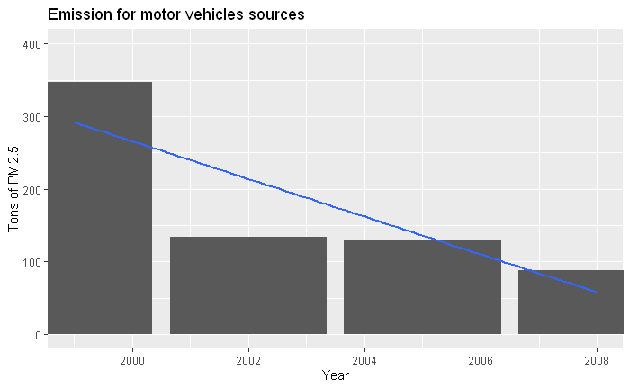

```r
g <- ggplot(totals_vehicle) + geom_col(aes(x = year, y = total)) + geom_smooth(method = lm, aes(x = year, y = total), se = FALSE)
g <- g + labs(x="Year", y ="Tons of PM2.5", title="Emission for motor vehicles sources")
g <- g + coord_cartesian(xlim=c(1999,2008),ylim=c(0,400))
print(g)
```

### 6. Compare emissions from motor vehicle sources in Baltimore City with emissions from motor vehicle sources in Los Angeles County, California *fips==“06037”*. Which city has seen greater changes over time in motor vehicle emissions?

```r
totals_vehicle_comp <- data %>% filter(type=="ON-ROAD", fips=="24510" | fips=="06037") %>%
  group_by(fips,year) %>%
  summarise(total = sum(Emissions)) %>%
  mutate(year=as.numeric(levels(year))[year])
```

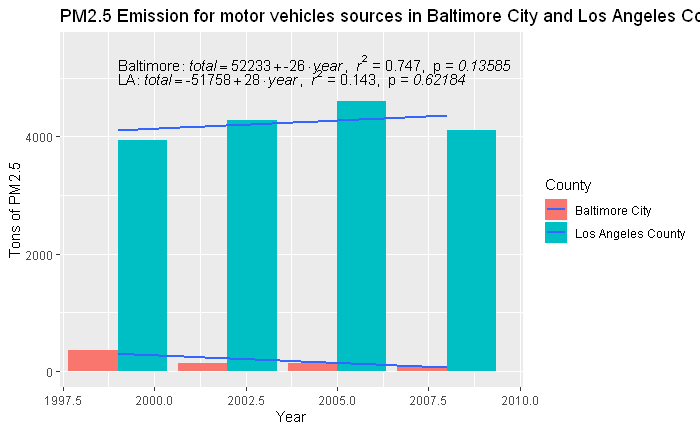

```r
g <- ggplot(totals_vehicle_comp, aes(x = year, y = total, fill=fips))
g <- g + geom_col(position="dodge")
g <- g + geom_smooth(se = FALSE, method = lm)
g <- g + coord_cartesian(xlim=c(1998,2009.5),ylim=c(0,5500))
g <- g + geom_text(aes(x = 1999, y = 5250, hjust="left",label = paste("Baltimore: ", lm_eqn(totals_vehicle_comp %>% filter(fips=="24510"), "total", "year"))), parse = TRUE)
g <- g + geom_text(aes(x = 1999, y = 5000, hjust="left", label = paste("LA: ", lm_eqn(totals_vehicle_comp %>% filter(fips=="06037"), "total", "year"))), parse = TRUE)
g <- g + scale_fill_discrete(name="County", labels=c("Baltimore City", "Los Angeles County"), aesthetics = c("colour", "fill"))
g <- g + labs(x="Year", y ="Tons of PM2.5", title="PM2.5 Emission for motor vehicles sources in Baltimore City and Los Angeles County (in tons)")
print(g)
```